# 3 Months catch data report (July-September)- WCS BAF

Author

Affiliation

Kaijage Laurian

Mwambao Coastal Community Network

Published

October 17, 2025

Modified

October 17, 2025

# 1 INTRODUCTION

This is a brief report on reef fish catch data from Kiuyu, Tumbe and Shumba collected between July to September. It provides highlights on the catch and CPUE trends, gear composition, vessel composition and spatial variability of selected indicator reef species.

In the reporting period one data checking and unannounced were conducted every month with the exception of September. This was due to the departmental limited personel during the month.

# 2 RESULTS

Data was collected between 05 July 2025 and 28 August 2025, from villages Kiuyu, Shumba, Tumbe. These data were recorded from 11 in Tumbe, 13 in Shumba, and 15 in Kiuyu fishing grounds. The recorded fish family richness were 17 in Tumbe, 13 in Shumba, and 21 in Kiuyu.

## 2.1 CPUE Trends

From these results, Tumbe recorded a mean catch of 4203.5 g, Shumba 3413.3 g, and Kiuyu 2844.9 g.

In Tumbe, the average catch weight ranged from 46 g to 2.3^{4} g, while CPUE varied between 15.33 g/fisher/day and 5750 g/fisher/day (Figure 1).

In Shumba, catch weights ranged from 374 g to 8940 g, with CPUE values between 35.37 g/fisher/day and 2235 g/fisher/day (Figure 1).

In Kiuyu, catch weights ranged from 95 g to 1.807^{4} g, and CPUE ranged between 12.83 g/fisher/day and 3215 g/fisher/day (Figure 1).

Trend analysis suggests that Kiuyu, Tumbe experienced increasing catches while Shumba exhibits a slight decline. CPUE patterns varied by location, Kiuyu no visible change, Shumba showed slight increase, and Tumbe experienced a consistent upward trend through the study period.

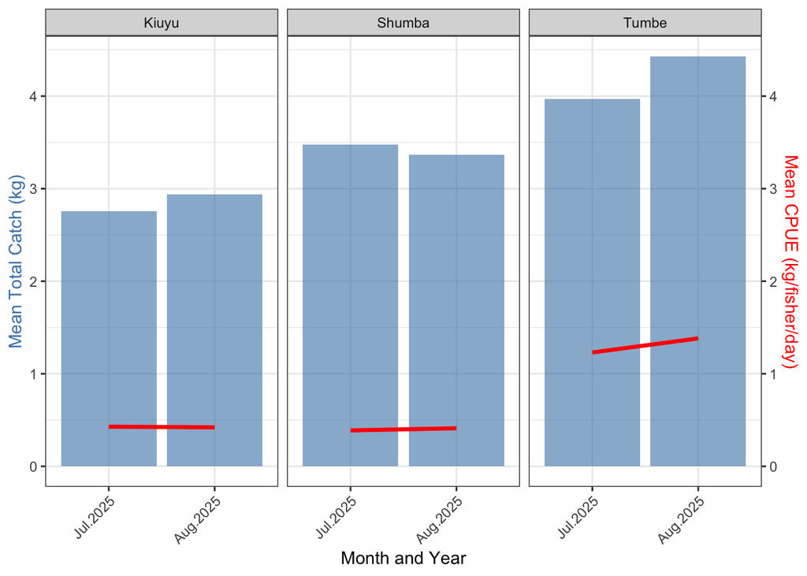

Figure 1: Temporal trends in mean total catch (blue bars) and mean catch per unit effort (CPUE, red line).

## 2.2 Selected Family Trends

In Tumbe, CPUE peaks were higher and more frequent, with notable catches of Labridae in July (1.6 g/fisher/day), Lethrinidae in August (1.5 kg/fisher/day), and Scaridae in August (1.5 kg/fisher/day) as seen in Figure 2.

From Figure 2, Kiuyu CPUE values were below 1 kg/fisher/day with high values recorded for Acanthuridae and Siganidae.

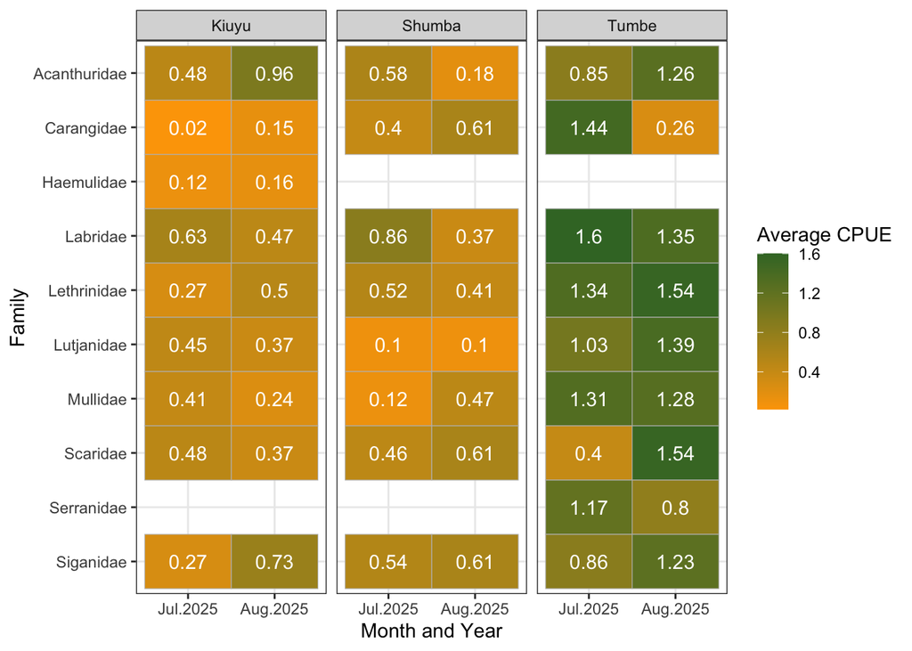

Figure 2: Temporal changes in selected reef families.

## 2.3 Fishing Grounds Use and CPUE

Table 1: The fishing ground CPUE from Kiuyu, Tumbe and Shumba calculated as g/fisher/day

| Fishing Grounds | Tumbe | Shumba | Kiuyu |
| --- | --- | --- | --- |
| Kitwani | 1,728.32 |  |  |
| Funguni | 1,647.84 |  |  |
| Mnarani | 1,514.00 | 140.05 |  |
| Jambani | 1,417.23 | 224.77 | 298.07 |
| Kongoo ya kati | 1,373.04 |  |  |
| Kisiwani | 1,322.38 |  |  |
| Imu | 1,239.78 | 665.78 |  |
| Farumuni | 1,191.60 | 311.95 | 533.21 |
| Uziwani | 1,112.75 | 362.52 | 764.40 |
| Mapakacha |  | 1,047.50 | 169.81 |
| Jiwe mtu |  | 832.50 |  |
| Kundeni | 764.04 | 220.96 |  |
| Kongoo |  | 748.89 | 385.08 |
| Kongoo mchele |  |  | 722.62 |
| Kongoo ya kiuyu |  | 665.02 |  |
| Mafunguni |  | 634.48 |  |
| Pwakuu |  |  | 513.65 |
| Matoma |  |  | 496.80 |
| Shangaa |  |  | 468.50 |
| Rasini | 426.42 |  |  |
| Mdomoni |  |  | 398.92 |
| Kongoo majini |  |  | 386.01 |
| Kekechu |  |  | 362.19 |
| Majimbuni |  |  | 325.80 |
| Kijiweni |  |  | 282.50 |
| Pwachi |  |  | 231.36 |
| Changa fusini |  | 176.98 |  |
| Kagera |  | 81.83 |  |

## 2.4 Gear use

Table 2: The Frequency of gear used during the data collection period

| Gear | Kiuyu | Tumbe | Shumba |
| --- | --- | --- | --- |
| Gillnet | 217 |  |  |
| Fish_trap |  | 209 |  |
| Speargun | 180 |  |  |
| Handline | 5 | 86 | 56 |
| Other |  |  | 61 |
| Seinnet |  | 8 | 26 |
| Fish_trap,Handline |  | 6 |  |
| Handline,Fish_trap |  | 2 |  |

Seine nets and fish traps/Handline-combo have recorded the highest amount of CPUE of 1,832.42 g/fisher/day and 1,582.50g/fisher /day respectively. The lowest CPUE of a gear was recorded in Shumba with the use of seine nets of 108.04 g/fisher/day (Table 3).

Table 3: The recorded CPUE in g/fisher/day for each gear recorded

| Gear | Tumbe | Shumba | Kiuyu |
| --- | --- | --- | --- |
| Seinnet | 1,832.42 | 108.04 |  |
| Handline,Fish_trap | 1,582.50 |  |  |
| Handline | 1,379.33 | 782.80 | 275.83 |
| Fish_trap | 1,157.39 |  |  |
| Fish_trap,Handline | 851.85 |  |  |
| Speargun |  |  | 431.74 |
| Gillnet |  |  | 322.80 |
| Other |  | 118.17 |  |

## 2.5 Vessel use

The most commonly used vessel type was the canoe in Kiuyu and Fiber boats in Tumbe, while boats with engines (Mashua) were more prevalent in Shumba (Table 4). Kiuyu recorded the use of all vessel types , whereas Tumbe utilized only canoes and fiber boats. In addition to canoes and fiber boats, Shumba also reported the use of Mashua.

Table 4

| Vessel used | Kiuyu | Tumbe | Shumba |
| --- | --- | --- | --- |
| Canoe | 261 | 142 | 27 |
| Fiber | 81 | 187 | 48 |
| Boat_ engine | 26 |  | 68 |
| Sail _boat | 25 |  |  |
| skin_diving | 5 |  |  |
| Ngwanda | 4 |  |  |